# Day eleven - 7/24

Marcus W. Beck, beck.marcus@epa.gov

### GIS and geospatial concepts

#### Basics

[Lecture](https://nceas.github.io/oss-lessons/spatial-data-gis-law/1-mon-spatial-data-intro.html)

Spatial data structures - shapefile is not the only one, look into GeoJSON

R creates extent objects - basically the boundin box

datum - spatial/vertical reference

Pixel - picture element

#### QGIS

Built in Python - can code in Python, works with GRASS, gdal. Good for checking your work from R.

Look up website for spatial references: http://spatialreference.org/

EPSG is mostly used in Python, proj4 is mostly usedin R - these are storage formats for defining the coordinate reference system.

gdal is an open-source GIS library, its like an open version of the guts of ArcGIS.

QGIS has lots of plugins from user community.

QGIS browser is like ArcGIS catalog.

Some processing of spatial data in R:

```r
# load these libraries
library(rgdal)
library(raster)
library(rgeos)
library(leaflet)

# import some data
coastlines <- readOGR('GISdata/ne-coastlines-10m/ne_10m_coastline.shp')
```

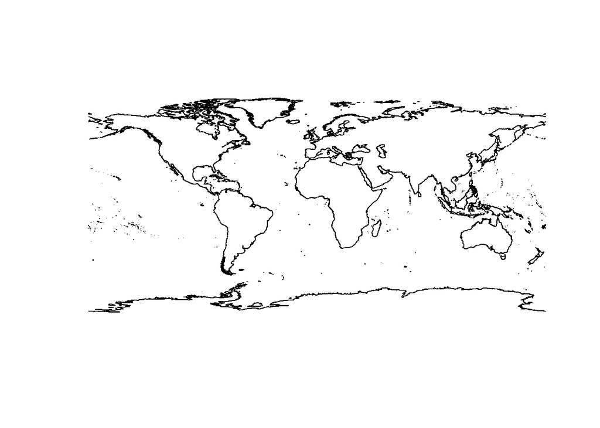

```r
# plot
plot(coastlines)
```

```r
# metadata
class(coastlines)
```

```
## [1] "SpatialLinesDataFrame"
## attr(,"package")
## [1] "sp"
```

```r
extent(coastlines) # spatial extent
```

```
## class       : Extent
## xmin        : -180
## xmax        : 180
## ymin        : -85.22194
## ymax        : 83.6341
```

```r
crs(coastlines) # coordinate reference system, proj 4
```

```
## CRS arguments:
##  +proj=longlat +datum=WGS84 +no_defs +ellps=WGS84 +towgs84=0,0,0
```

```r
ext_obj <- extent(coastlines) # this is an S4 class
ext_obj@xmin
```

```
## [1] -180
```

Simplify our data with simplify:

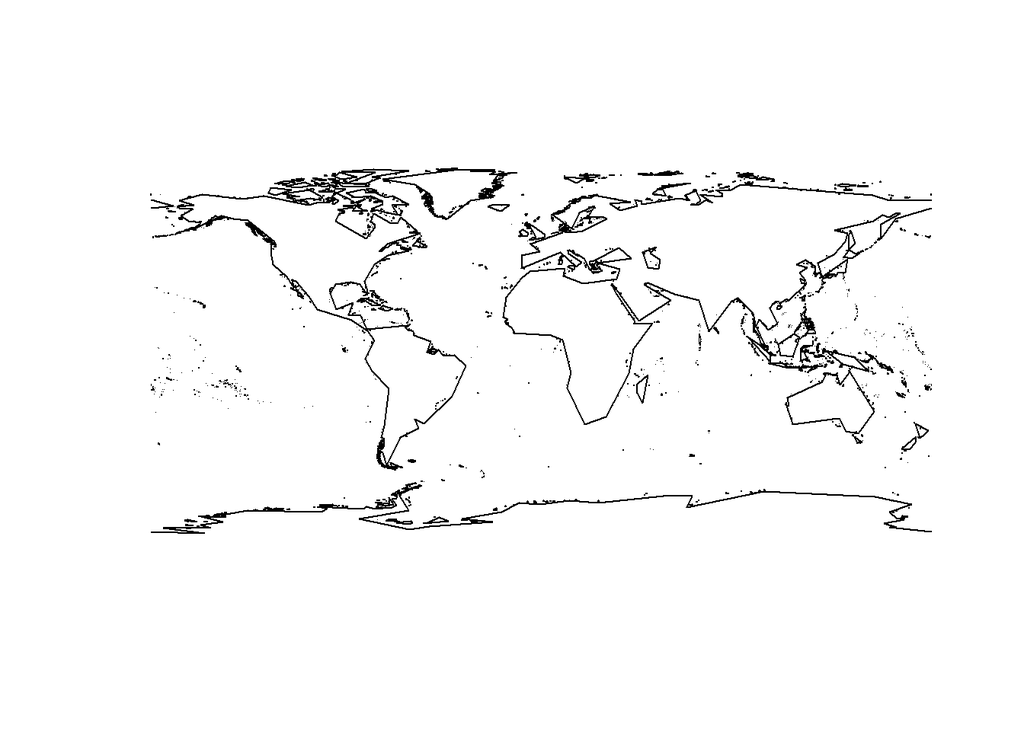

```r
# tol is trial and error, the larger the number the more simplification
coastlines_simp <- gSimplify(coastlines, tol = 3, topologyPreserve = TRUE)
plot(coastlines_simp)
```

Leaflet example:

```r
leaflet(coastlines_simp) %>%
  addTiles() %>%
  addPolylines(color = 'red', weight = 3, smoothFactor = 0.5)
```

[interactive chart not shown]

Conflicting coordinate systems plots nothing:

```r
loc <- readOGR('GISdata/study-area/study-area-merc.shp')
usl <- readOGR('GISdata/us-boundaries/us_bound_pop.shp')
crs(loc)
```

```
## CRS arguments:
##  +proj=merc +lon_0=0 +lat_ts=0 +x_0=0 +y_0=0 +datum=WGS84 +units=m
## +no_defs +ellps=WGS84 +towgs84=0,0,0
```

```r
crs(usl)
```

```
## CRS arguments:
##  +proj=longlat +datum=WGS84 +no_defs +ellps=WGS84 +towgs84=0,0,0
```

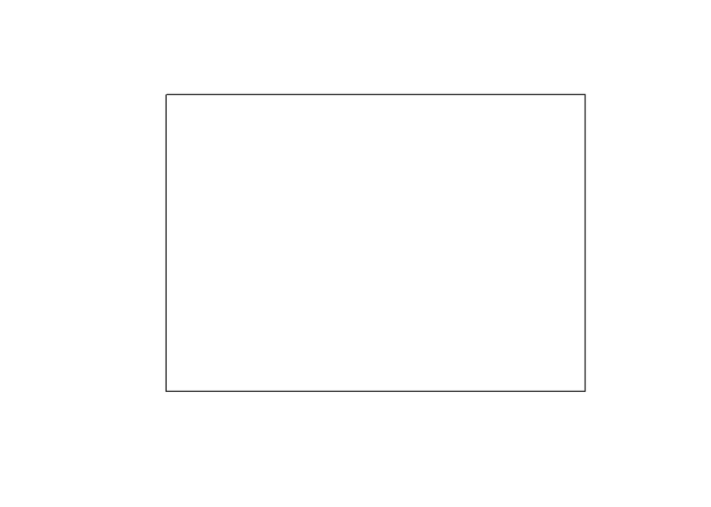

```r
plot(loc)
plot(usl, add = TRUE)
```

Should look like this:

```r
loc <- readOGR('GISdata/study-area/study-area.shp')
usl <- readOGR('GISdata/us-boundaries/us_bound_pop.shp')
crs(loc)
```

```
## CRS arguments:
##  +proj=longlat +datum=WGS84 +no_defs +ellps=WGS84 +towgs84=0,0,0
```

```r
crs(usl)
```

```
## CRS arguments:
##  +proj=longlat +datum=WGS84 +no_defs +ellps=WGS84 +towgs84=0,0,0
```

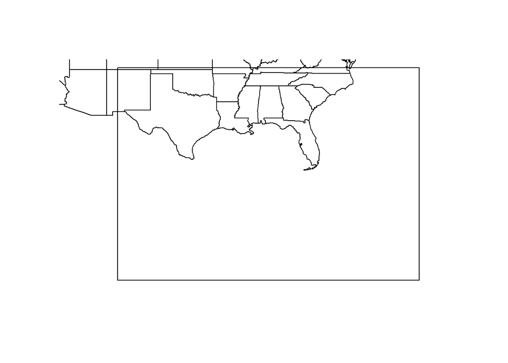

```r
plot(loc)
plot(usl, add = TRUE)
```

So you can also change the coordinate system:

```r
loc <- readOGR('GISdata/study-area/study-area-merc.shp')
```

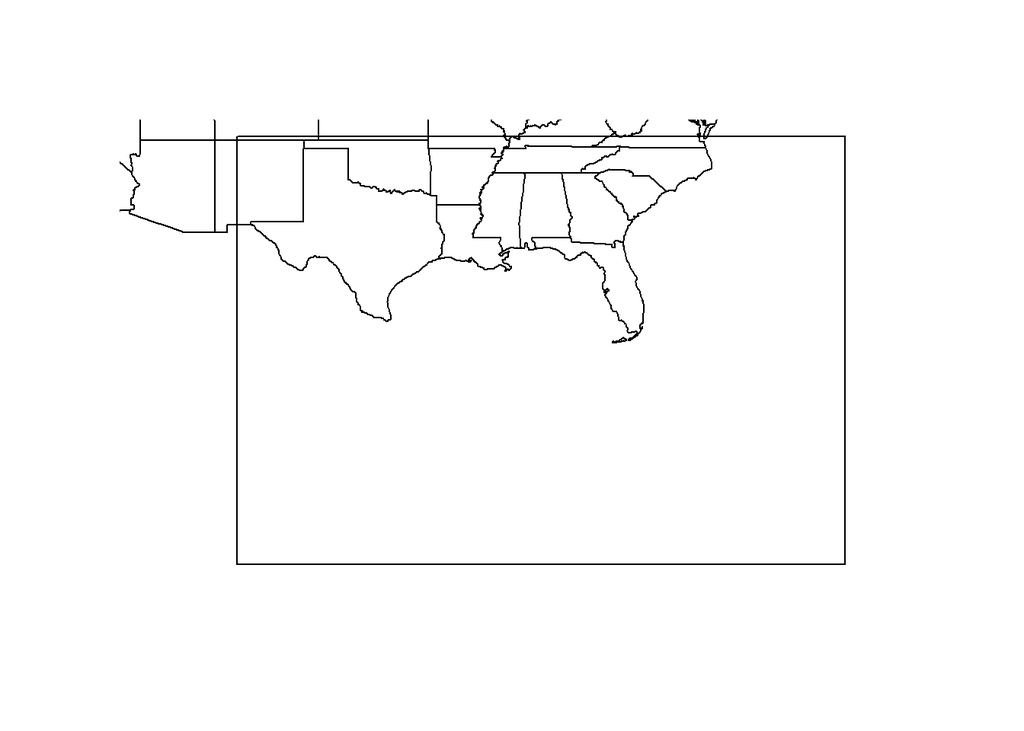

```r
locnew <- spTransform(loc,
  CRS("+proj=longlat +datum=WGS84 +no_defs +ellps=WGS84 +towgs84=0,0,0"))

plot(locnew)
plot(usl, add = TRUE)
```

Clip with **gIntersection**

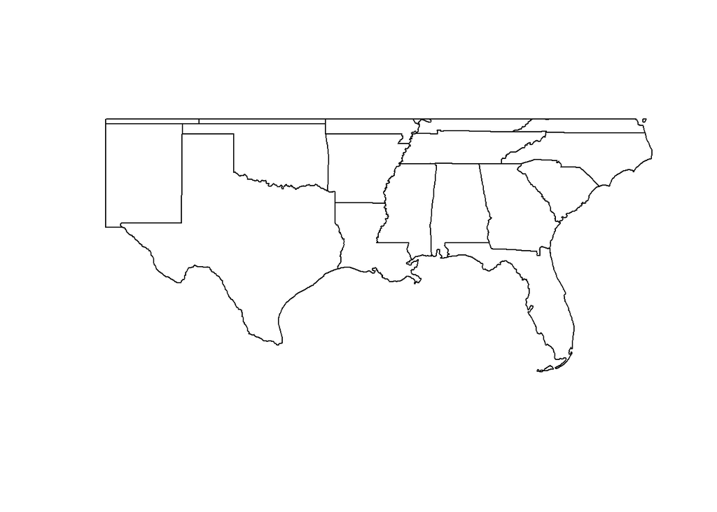

```r
clip <- gIntersection(locnew, usl, byid = TRUE, drop_lower_td = TRUE)
plot(clip)
```

Or clip this way with **crop**, note argument order switch.

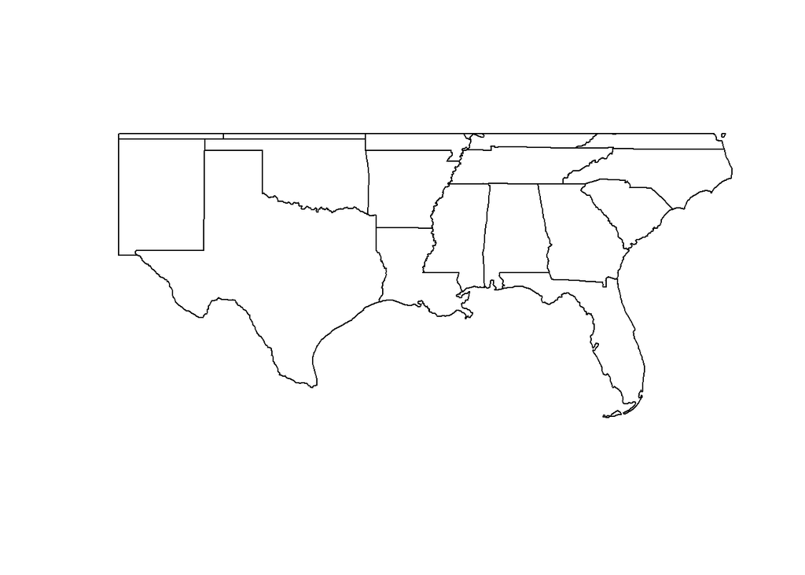

```r
clip <- crop(usl, locnew)
plot(clip)
```

General global layers: https://www.naturalearthdata.com and an R package to access https://github.com/ropenscilabs/rnaturalearth

Raster stuff:

```r
# import a hillshade layer
hshade <- raster('GISdata/hillshade/hillshade_3395.tif')
crs(hshade)
```

```
## CRS arguments:
##  +proj=merc +lon_0=0 +k=1 +x_0=0 +y_0=0 +datum=WGS84 +units=m
## +no_defs +ellps=WGS84 +towgs84=0,0,0
```

```r
extent(hshade)
```

```
## class       : Extent
## xmin        : -22247360
## xmax        : 817179.7
## ymin        : -7379629
## ymax        : 14614716
```

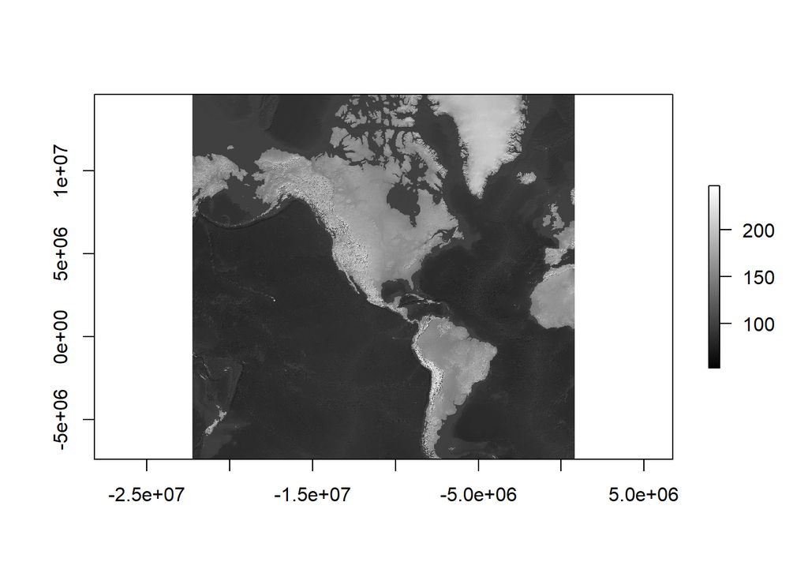

```r
plot(hshade, col = grey(1:100/100))
```

Reproject the raster:

```r
hshade <- projectRaster(hshade, crs = crs(usl))
crs(hshade)
```

```
## CRS arguments:
##  +proj=longlat +datum=WGS84 +no_defs +ellps=WGS84 +towgs84=0,0,0
```

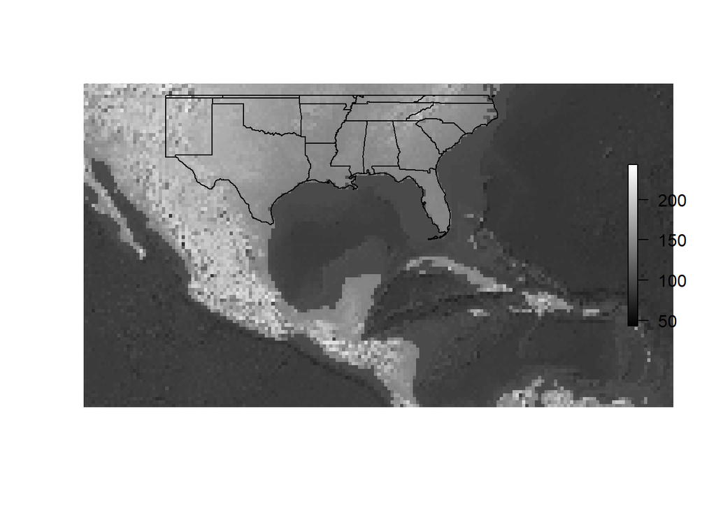

```r
plot(locnew)
plot(hshade, col = grey(1:100/100), add = T )
plot(clip, add = TRUE)
```

### Publishing maps to the web

Tiling, makes zooming/panning very easy, different layers at different resolutions are downloaded on the fly depending on zoom and location. This is what leaflet is doing.